# Testing the new mosdef functions on an existing report

Leon

2023-12-06

```r
library("DESeq2")
library("edgeR")
library("hexbin")
library("latticeExtra")
```

```r
library("gplots")
library("RColorBrewer")
library("topGO")
library("org.Mm.eg.db")
library("gplots")
library("genefilter")
library("rtracklayer")
library("xtable")
library("GO.db")
library("goseq")
library("GenomicFeatures")
library("ReactomePA")
library("dplyr")
library("NMF")
library("pheatmap")
library("GOplot")
library("knitr")
library("pcaExplorer")
library("DT")
library("ideal")
library("GeneTonic")
library("clusterProfiler")
library("ggrepel")
devtools::load_all(".")
library("mosdef")
```

```r
dds_lisamarie <- readRDS("dds_lisamarie_salmon.RDS")
```

# 1 Sample overview

**All samples in one interactive table**

RNA-seq samples were derived from 18 different experiments, for a total of 6 experimental groups (given by the combination of cells AND treatment)

For each group, biological replicates were sequenced (2-4 each).

For more information and an overview, see the tables in the main text.

This report provides a detailed overview of the steps taken to perform a comprehensive exploratory data analysis.

```r
DT::datatable(as.data.frame(dds_lisamarie@colData))
```

|  | names | sample_id | cells | treatment | group | id |
| --- | --- | --- | --- | --- | --- | --- |
| NK_untrt_d1 | 0246_TP12_002_CE_NSP_1TR1_SL1 | bc11 | NK | untrt | NK_untrt | NK_untrt_d1 |
| NK_BV6_d1 | 0246_TP12_003_CE_NSP_1TR1_SL1 | bc11 | NK | BV6 | NK_BV6 | NK_BV6_d1 |
| NK_RH30_untrt_d1 | 0246_TP12_004_CE_NSP_1TR1_SL1 | bc11 | NK_RH30 | untrt | NK_RH30_untrt | NK_RH30_untrt_d1 |
| NK_RH30_BV6_d1 | 0246_TP12_005_CE_NSP_1TR1_SL1 | bc11 | NK_RH30 | BV6 | NK_RH30_BV6 | NK_RH30_BV6_d1 |
| RH30_untrt_d1 | 0246_TP12_006_CE_NSP_1TR1_SL1 | bc11 | RH30 | untrt | RH30_untrt | RH30_untrt_d1 |
| NK_untrt_d2 | 0246_TP12_008_CE_NSP_1TR1_SL1 | bc13 | NK | untrt | NK_untrt | NK_untrt_d2 |
| NK_BV6_d2 | 0246_TP12_009_CE_NSP_1TR1_SL1 | bc13 | NK | BV6 | NK_BV6 | NK_BV6_d2 |
| NK_RH30_BV6_d2 | 0246_TP12_011_CE_NSP_1TR1_SL1 | bc13 | NK_RH30 | BV6 | NK_RH30_BV6 | NK_RH30_BV6_d2 |
| RH30_untrt_d2 | 0246_TP12_012_CE_NSP_1TR1_SL1 | bc13 | RH30 | untrt | RH30_untrt | RH30_untrt_d2 |
| RH30_BV6_d2 | 0246_TP12_013_CE_NSP_1TR1_SL1 | bc13 | RH30 | BV6 | RH30_BV6 | RH30_BV6_d2 |

[output cut: 8 more lines]

# 2 QC on the samples

**the same as in the example report**

See multiQC report for overview.

# 3 Quantification and exploration

**the same as in the example report** We proceed from the salmon-based approach.

Let’s check the number of assigned reads per sample as a proxy of the sequencing depth

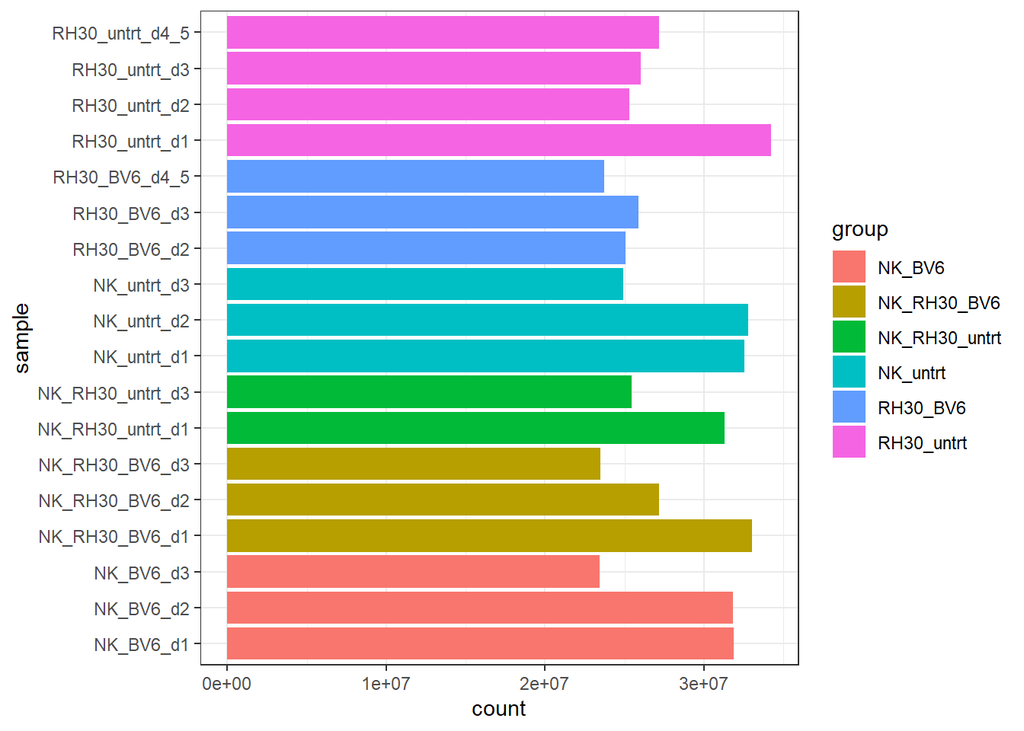

```r
myd <- data.frame(
  counts = colSums(counts(dds_lisamarie)),
  group = dds_lisamarie$group,
  sample = colnames(dds_lisamarie))
ggplot(myd, aes(x = sample,weight = counts, fill = group)) + geom_bar() + theme(axis.text.x = element_text(angle = 90, hjust = 1)) + theme_bw() + coord_flip()
```

```r
FDR <- 0.05
```

```r
# removed helper funcs but not sure what the point of alltheresults is
#used mosdef helperfunctions
alltheresults <- function(resuSet, dds_obj, contrast, FDR, anno_df, anns, species) {

  # id_contrast <- paste0(contrast[2],"_vs_",contrast[3])
  id_contrast <- contrast
  resuSet[[id_contrast]] <- list()

  # mycoef <- resultsNames(dds_obj)[2]
  mycoef <- contrast

  message("Extracting results...")
  resuSet[[id_contrast]][["res_DESeq"]] <- results(dds_obj,name = mycoef, alpha = FDR)
  message("Performing LFC shrinkage...")
  resuSet[[id_contrast]][["res_DESeq"]] <- lfcShrink(dds_obj,coef = mycoef,res = resuSet[[id_contrast]][["res_DESeq"]], type = "apeglm")
  resuSet[[id_contrast]][["res_DESeq"]]$SYMBOL <- anno_df$gene_name[match(rownames(resuSet[[id_contrast]][["res_DESeq"]]), anno_df$gene_id)]

  message("Summary MAplot...")
  summary(resuSet[[id_contrast]][["res_DESeq"]])
  resuSet[[id_contrast]][["maplot_res"]] <-
    ideal::plot_ma(resuSet[[id_contrast]][["res_DESeq"]], ylim = c(-2,2), title = id_contrast)

  message("Extracting tables...")
  resuSet[[id_contrast]][["tbl_res_all"]] <- deseqresult2df(resuSet[[id_contrast]][["res_DESeq"]])
  resuSet[[id_contrast]][["tbl_res_all"]]$geneSymbol <- anno_df$gene_name[match(resuSet[[id_contrast]][["tbl_res_all"]]$id, anno_df$gene_id)]
  resuSet[[id_contrast]][["tbl_res_all"]]$description <- anns$description[match(resuSet[[id_contrast]][["tbl_res_all"]]$id, anns$ensembl_gene_id)]

  message("Extracting DEtables...")
  resuSet[[id_contrast]][["tbl_res_DE"]] <- deseqresult2df(resuSet[[id_contrast]][["res_DESeq"]],FDR = FDR)
  resuSet[[id_contrast]][["tbl_res_DE"]]$geneSymbol <- anno_df$gene_name[match(resuSet[[id_contrast]][["tbl_res_DE"]]$id, anno_df$gene_id)]
  resuSet[[id_contrast]][["tbl_res_DE"]]$description <- anns$description[match(resuSet[[id_contrast]][["tbl_res_DE"]]$id, anns$ensembl_gene_id)]
  resuSet[[id_contrast]][["tbl_res_DE"]]$chromosome_name <- anns$chromosome_name[match(resuSet[[id_contrast]][["tbl_res_DE"]]$id, anns$ensembl_gene_id)]

  if(nrow(resuSet[[id_contrast]][["tbl_res_DE"]]) > 0) {
    message("Generating interactive DEtable...")
    resuSet[[id_contrast]][["etbl_res_DE"]] <- resuSet[[id_contrast]][["tbl_res_DE"]]
    resuSet[[id_contrast]][["etbl_res_DE"]]$id <- create_link_ENS(resuSet[[id_contrast]][["etbl_res_DE"]]$id, species = species)
    resuSet[[id_contrast]][["etbl_res_DE"]]$geneSymbol <- create_link_NCBI(resuSet[[id_contrast]][["etbl_res_DE"]]$geneSymbol)
  }

  mybuttons <- c('copy', 'csv', 'excel', 'pdf', 'print')
  datatable(resuSet[[id_contrast]][["etbl_res_DE"]],caption = paste0(id_contrast,", DE genes"),escape=F, extensions = 'Buttons', options = list(dom = 'Bfrtip',buttons = mybuttons))

  return(resuSet)
}
```

# 4 Gene annotation

**same as in the example report** This information comes in very handy to aovid having just ensembl ids, which are not so friendly to the eye of the scientist, but are nicely unique and stable over time

```r
library("org.Hs.eg.db")
# anno_df <- pcaExplorer::get_annotation_orgdb(dds_lisamarie, "org.Hs.eg.db", "SYMBOL")
anno_df <- pcaExplorer::get_annotation_orgdb(dds_lisamarie, "org.Hs.eg.db", "ENSEMBL")

library("biomaRt")
mart <- useMart(biomart="ENSEMBL_MART_ENSEMBL", dataset="hsapiens_gene_ensembl")
anns <- getBM(attributes = c("ensembl_gene_id", "external_gene_name", "description"),
              filters = "ensembl_gene_id",
              # filters = "external_gene_name",
              values = rownames(dds_lisamarie),
              mart = mart)
# anns <- anns[match(rownames(dds_lisamarie), anns$external_gene_name), ]
anns <- anns[match(rownames(dds_lisamarie), anns$ensembl_gene_id), ]
save(anns,file="biomart_anno_lisamarie.RData")
# then will be re-sorted according to the table to attach it to
```

```r
library("org.Hs.eg.db")
anno_df <- pcaExplorer::get_annotation_orgdb(dds_lisamarie, "org.Hs.eg.db", "ENSEMBL")
 load("biomart_anno_lisamarie.RData")
anns_df <- anns
# for taking over from biomart

# colnames(anns_df) <- c("gene_id", "gene_name", "description")
rownames(anno_df) <- rownames(dds_lisamarie)
```

# 5 EDA & DE

**same as example report** ## Data exploration

We first check how the whole set of samples looks like - the control sample included is a singleton, so there is not too much to do about it…

```r
rld_lisamarie <- rlog(dds_lisamarie)
```

```
## using 'avgTxLength' from assays(dds), correcting for library size
```

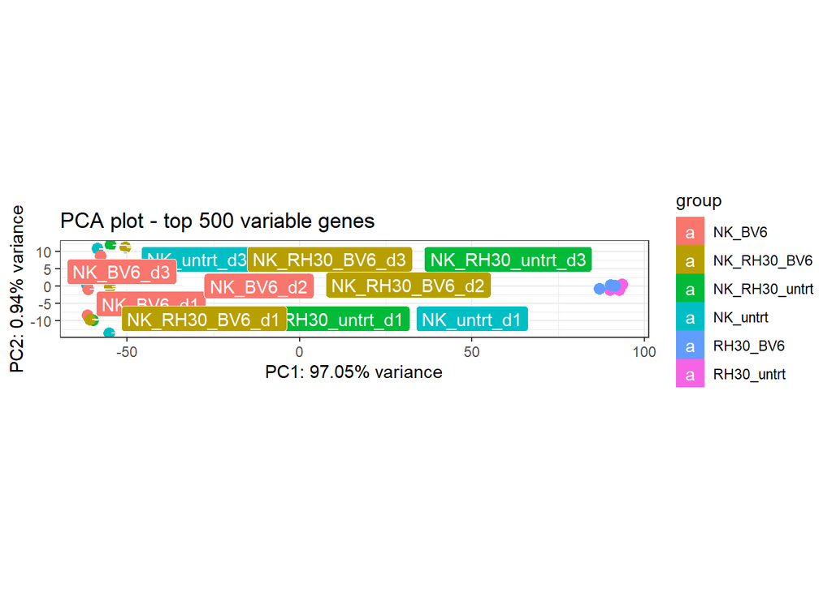

```r
pcaplot(rld_lisamarie, "group", ellipse = FALSE, text_labels = TRUE)
```

To appreciate the individual differences, we do split up the into individual subsets, for each cell type. *removed the vst parts here because the pcakge wouldn’t install*

```r
dds_NK <- dds_lisamarie[, dds_lisamarie$cells == "NK"]
dds_NKRH30 <- dds_lisamarie[, dds_lisamarie$cells == "NK_RH30"]
dds_RH30 <- dds_lisamarie[, dds_lisamarie$cells == "RH30"]
```

We set up the design and adjust the factor levels after subsetting

```r
design(dds_NK) <- ~sample_id + treatment
design(dds_NKRH30) <- ~sample_id + treatment
design(dds_RH30) <- ~sample_id + treatment

dds_NK$sample_id <- droplevels(dds_NK$sample_id)
dds_NK$group <- droplevels(dds_NK$group)

dds_NKRH30$sample_id <- droplevels(dds_NKRH30$sample_id)
dds_NKRH30$group <- droplevels(dds_NKRH30$group)

dds_RH30$sample_id <- droplevels(dds_RH30$sample_id)
dds_RH30$group <- droplevels(dds_RH30$group)
```

This is the key step basically - accounting for the donor of origin!

## 5.1 Data DE

```r
dds_NK <- DESeq(dds_NK)
```

```
## using 'avgTxLength' from assays(dds), correcting for library size
```

```r
dds_NKRH30 <- DESeq(dds_NKRH30)
```

```
## using 'avgTxLength' from assays(dds), correcting for library size
```

```r
dds_RH30 <- DESeq(dds_RH30)
```

```
## using 'avgTxLength' from assays(dds), correcting for library size
```

```r
summary(results(dds_NK), alpha = FDR)
```

```
##
## out of 35492 with nonzero total read count
## adjusted p-value < 0.05
## LFC > 0 (up)       : 143, 0.4%
## LFC < 0 (down)     : 150, 0.42%
## outliers [1]       : 0, 0%
## low counts [2]     : 22537, 63%
## (mean count < 31)
## [1] see 'cooksCutoff' argument of ?results
## [2] see 'independentFiltering' argument of ?results
```

```r
summary(results(dds_NKRH30), alpha = FDR)
```

```
##
## out of 33834 with nonzero total read count
## adjusted p-value < 0.05
## LFC > 0 (up)       : 1, 0.003%
## LFC < 0 (down)     : 0, 0%
## outliers [1]       : 0, 0%
## low counts [2]     : 0, 0%
## (mean count < 0)
## [1] see 'cooksCutoff' argument of ?results
## [2] see 'independentFiltering' argument of ?results
```

```r
summary(results(dds_RH30), alpha = FDR)
```

```
##
## out of 37077 with nonzero total read count
## adjusted p-value < 0.05
## LFC > 0 (up)       : 208, 0.56%
## LFC < 0 (down)     : 175, 0.47%
## outliers [1]       : 0, 0%
## low counts [2]     : 20856, 56%
## (mean count < 7)
## [1] see 'cooksCutoff' argument of ?results
## [2] see 'independentFiltering' argument of ?results
```

```r
resultsNames(dds_NK)
```

```
## [1] "Intercept"              "sample_id_bc13_vs_bc11" "sample_id_bc14_vs_bc11"
## [4] "treatment_BV6_vs_untrt"
```

```r
resultsNames(dds_NKRH30)
```

```
## [1] "Intercept"              "sample_id_bc13_vs_bc11" "sample_id_bc14_vs_bc11"
## [4] "treatment_BV6_vs_untrt"
```

```r
resultsNames(dds_RH30)
```

```
## [1] "Intercept"                 "sample_id_bc13_vs_bc11"
## [3] "sample_id_bc14_vs_bc11"    "sample_id_bc25_27_vs_bc11"
## [5] "treatment_BV6_vs_untrt"
```

compare with “the caveman approach”

```r
dds_lisamarie
```

```
## class: DESeqDataSet
## dim: 60230 18
## metadata(7): tximetaInfo quantInfo ... txdbInfo version
## assays(3): counts abundance avgTxLength
## rownames(60230): ENSG00000000003 ENSG00000000005 ... ENSG00000288724
##   ENSG00000288725
## rowData names(2): gene_id tx_ids
## colnames(18): NK_untrt_d1 NK_BV6_d1 ... RH30_untrt_d4_5 RH30_BV6_d4_5
## colData names(6): names sample_id ... group id
```

```r
design(dds_lisamarie)
```

```
## ~group
```

```r
dds_lisamarie <- DESeq(dds_lisamarie)
```

```
## using 'avgTxLength' from assays(dds), correcting for library size
```

```r
resultsNames(dds_lisamarie)
```

```
## [1] "Intercept"                     "group_NK_RH30_BV6_vs_NK_BV6"
## [3] "group_NK_RH30_untrt_vs_NK_BV6" "group_NK_untrt_vs_NK_BV6"
## [5] "group_RH30_BV6_vs_NK_BV6"      "group_RH30_untrt_vs_NK_BV6"
```

```r
summary(results(dds_lisamarie, contrast = c("group", "NK_BV6", "NK_untrt"), alpha = FDR))
```

```
##
## out of 42242 with nonzero total read count
## adjusted p-value < 0.05
## LFC > 0 (up)       : 3, 0.0071%
## LFC < 0 (down)     : 7, 0.017%
## outliers [1]       : 48, 0.11%
## low counts [2]     : 20015, 47%
## (mean count < 2)
## [1] see 'cooksCutoff' argument of ?results
## [2] see 'independentFiltering' argument of ?results
```

```r
summary(results(dds_lisamarie, contrast = c("group", "NK_RH30_BV6", "NK_RH30_untrt"), alpha = FDR))
```

```
##
## out of 42242 with nonzero total read count
## adjusted p-value < 0.05
## LFC > 0 (up)       : 1, 0.0024%
## LFC < 0 (down)     : 0, 0%
## outliers [1]       : 48, 0.11%
## low counts [2]     : 0, 0%
## (mean count < 0)
## [1] see 'cooksCutoff' argument of ?results
## [2] see 'independentFiltering' argument of ?results
```

```r
summary(results(dds_lisamarie, contrast = c("group", "RH30_BV6", "RH30_untrt"), alpha = FDR))
```

```
##
## out of 42242 with nonzero total read count
## adjusted p-value < 0.05
## LFC > 0 (up)       : 92, 0.22%
## LFC < 0 (down)     : 18, 0.043%
## outliers [1]       : 48, 0.11%
## low counts [2]     : 21617, 51%
## (mean count < 3)
## [1] see 'cooksCutoff' argument of ?results
## [2] see 'independentFiltering' argument of ?results
```

<– this one does not account for the donor of origin!

### Generating the results

```r
myresuSet_lisamarie <- list()
```

```r
myresuSet_lisamarie <- alltheresults(
  myresuSet_lisamarie, dds_NK,
  contrast = c("treatment_BV6_vs_untrt"), FDR = FDR,
  anno_df = anno_df, anns = anns_df, species = "Homo_sapiens")
```

```
##
## out of 35492 with nonzero total read count
## adjusted p-value < 0.05
## LFC > 0 (up)       : 143, 0.4%
## LFC < 0 (down)     : 150, 0.42%
## outliers [1]       : 0, 0%
## low counts [2]     : 22537, 63%
## (mean count < 31)
## [1] see 'cooksCutoff' argument of ?results
## [2] see 'independentFiltering' argument of ?results
```

```r
names(myresuSet_lisamarie)[1] <- "NK_BV6_vs_untrt"

myresuSet_lisamarie <- alltheresults(
  myresuSet_lisamarie, dds_NKRH30,
  contrast = c("treatment_BV6_vs_untrt"), FDR = FDR,
  anno_df = anno_df, anns = anns_df, species = "Homo_sapiens")
```

```
##
## out of 33834 with nonzero total read count
## adjusted p-value < 0.05
## LFC > 0 (up)       : 1, 0.003%
## LFC < 0 (down)     : 0, 0%
## outliers [1]       : 0, 0%
## low counts [2]     : 0, 0%
## (mean count < 0)
## [1] see 'cooksCutoff' argument of ?results
## [2] see 'independentFiltering' argument of ?results
```

```r
names(myresuSet_lisamarie)[2] <- "NKRH30_BV6_vs_untrt"

myresuSet_lisamarie <- alltheresults(
  myresuSet_lisamarie, dds_RH30,
  contrast = c("treatment_BV6_vs_untrt"), FDR = FDR,
  anno_df = anno_df, anns = anns_df, species = "Homo_sapiens")
```

```
##
## out of 37077 with nonzero total read count
## adjusted p-value < 0.05
## LFC > 0 (up)       : 209, 0.56%
## LFC < 0 (down)     : 177, 0.48%
## outliers [1]       : 0, 0%
## low counts [2]     : 21551, 58%
## (mean count < 10)
## [1] see 'cooksCutoff' argument of ?results
## [2] see 'independentFiltering' argument of ?results
```

```r
names(myresuSet_lisamarie)[3] <- "RH30_BV6_vs_untrt"
```

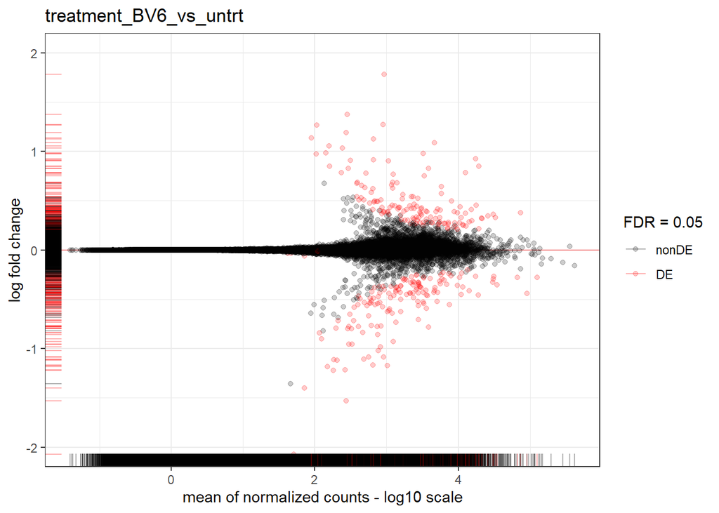

```r
myresuSet_lisamarie$NK_BV6_vs_untrt$maplot_res
```

```r
DT::datatable(myresuSet_lisamarie$NK_BV6_vs_untrt$etbl_res_DE, escape = FALSE, rownames = FALSE)
```

| id | baseMean | log2FoldChange | lfcSE | pvalue | padj | SYMBOL | geneSymbol | description |
| --- | --- | --- | --- | --- | --- | --- | --- | --- |
| ENSG00000143333 | 494.4216090824706 | 2.876382174975544 | 0.2277239293840732 | 1.632384537646804e-38 | 2.114754168521435e-34 | RGS16 | RGS16@NCBI | regulator of G protein signaling 16 [Source:HGNC Symbol;Acc:HGNC:9997] |
| ENSG00000100906 | 4623.046738699451 | 1.089445370774219 | 0.1084325362457926 | 3.517685194878928e-25 | 2.278580584982826e-21 | NFKBIA | NFKBIA@NCBI | NFKB inhibitor alpha [Source:HGNC Symbol;Acc:HGNC:7797] |
| ENSG00000140564 | 19218.21160782453 | 0.8503337093770614 | 0.0881967653319074 | 7.781683860987438e-23 | 3.360390480636408e-19 | FURIN | FURIN@NCBI | furin, paired basic amino acid cleaving enzyme [Source:HGNC Symbol;Acc:HGNC:8568] |
| ENSG00000153234 | 925.8955114096743 | 1.779168096922204 | 0.1917597271917484 | 2.863542486064053e-22 | 8.950999754930978e-19 | NR4A2 | NR4A2@NCBI | nuclear receptor subfamily 4 group A member 2 [Source:HGNC Symbol;Acc:HGNC:7981] |
| ENSG00000277632 | 17308.58871182569 | 0.9223737339925007 | 0.09912711980020429 | 3.45465061942531e-22 | 8.950999754930978e-19 | CCL3 | CCL3@NCBI | C-C motif chemokine ligand 3 [Source:HGNC Symbol;Acc:HGNC:10627] |
| ENSG00000226979 | 3251.209465922888 | 0.9771985496715344 | 0.118262550581471 | 6.084241258572846e-18 | 1.313689091746854e-14 | LTA | LTA@NCBI | lymphotoxin alpha [Source:HGNC Symbol;Acc:HGNC:6709] |
| ENSG00000111537 | 900.040088777162 | 1.273012873521105 | 0.1565716980799242 | 1.617237881617664e-17 | 2.993045250908119e-14 | IFNG | IFNG@NCBI | interferon gamma [Source:HGNC Symbol;Acc:HGNC:5438] |
| ENSG00000120875 | 3830.482249722722 | 0.8287460200497097 | 0.1033281562581009 | 5.215119473502856e-17 | 8.445234097403688e-14 | DUSP4 | DUSP4@NCBI | dual specificity phosphatase 4 [Source:HGNC Symbol;Acc:HGNC:3070] |
| ENSG00000109107 | 3842.335883626277 | -0.7825166914924324 | 0.1011334868905627 | 5.149747432781809e-16 | 7.412775332409815e-13 | ALDOC | ALDOC@NCBI | aldolase, fructose-bisphosphate C [Source:HGNC Symbol;Acc:HGNC:418] |
| ENSG00000162894 | 1243.470004419979 | -0.9283795235671779 | 0.1208926084719545 | 8.872029045885159e-16 | 1.149371362894422e-12 | FCMR | FCMR@NCBI | Fc mu receptor [Source:HGNC Symbol;Acc:HGNC:14315] |

[output cut: 283 more lines]

### 5.1.1 Spot checks - some genes more in detail

… at some genes specified in the presentation

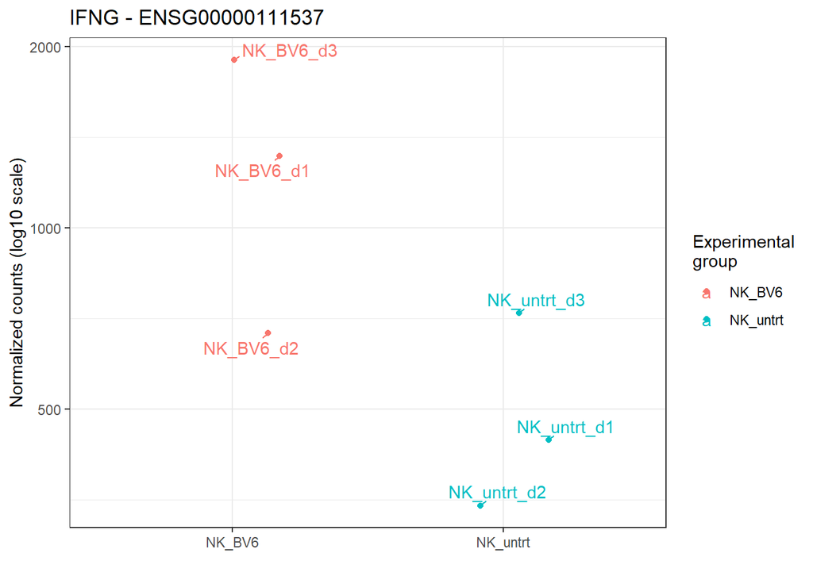

```r
gene_plot(dds_NK, "ENSG00000111537", annotation_obj = anno_df, intgroup = "group")
```

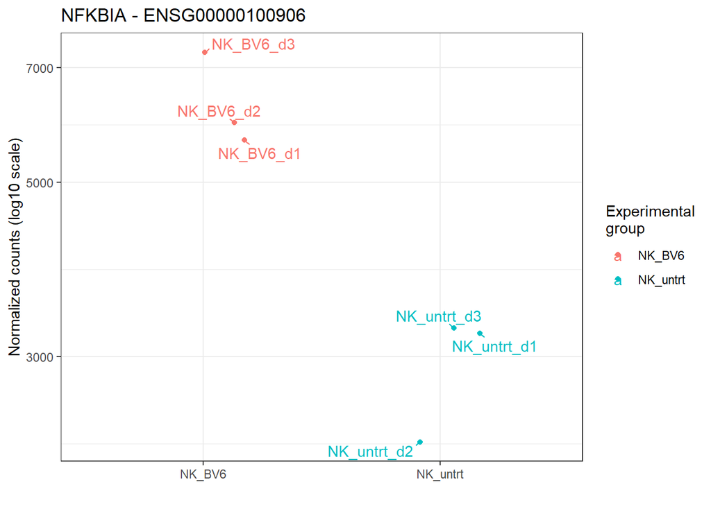

```r
gene_plot(dds_NK, "ENSG00000100906", annotation_obj = anno_df, intgroup = "group")
```

Example of the buttonifiers **Here mosdef begins**

```r
myresuSet_lisamarie[[1]][["etbl_res_DE_test"]] <- buttonifier(myresuSet_lisamarie[[1]][["etbl_res_DE"]], output_format = "DF")

myresuSet_lisamarie[[2]][["etbl_res_DE_test"]] <- buttonifier(myresuSet_lisamarie[[1]][["etbl_res_DE"]], new_cols =c("NCBI", "HPA"), output_format = "DF")


#showing all the buttons in one
myresuSet_lisamarie[[3]][["etbl_res_DE_test"]] <- buttonifier(myresuSet_lisamarie[[1]][["etbl_res_DE"]], new_cols =c("GC", "NCBI", "GTEX", "UNIPROT", "dbPTM", "HPA"), output_format = "DF")
```

Now for the display:

```r
DT::datatable(myresuSet_lisamarie[[1]][["etbl_res_DE_test"]],escape=FALSE, rownames=FALSE )
```

| id | baseMean | log2FoldChange | lfcSE | pvalue | padj | geneSymbol | description | SYMBOL_GC | SYMBOL_UNIPROT |
| --- | --- | --- | --- | --- | --- | --- | --- | --- | --- |
| ENSG00000143333 | 494.4216090824706 | 2.876382174975544 | 0.2277239293840732 | 1.632384537646804e-38 | 2.114754168521435e-34 | RGS16@NCBI | regulator of G protein signaling 16 [Source:HGNC Symbol;Acc:HGNC:9997] | RGS16@GeneCards | RGS16@UNIPROT |
| ENSG00000100906 | 4623.046738699451 | 1.089445370774219 | 0.1084325362457926 | 3.517685194878928e-25 | 2.278580584982826e-21 | NFKBIA@NCBI | NFKB inhibitor alpha [Source:HGNC Symbol;Acc:HGNC:7797] | NFKBIA@GeneCards | NFKBIA@UNIPROT |
| ENSG00000140564 | 19218.21160782453 | 0.8503337093770614 | 0.0881967653319074 | 7.781683860987438e-23 | 3.360390480636408e-19 | FURIN@NCBI | furin, paired basic amino acid cleaving enzyme [Source:HGNC Symbol;Acc:HGNC:8568] | FURIN@GeneCards | FURIN@UNIPROT |
| ENSG00000153234 | 925.8955114096743 | 1.779168096922204 | 0.1917597271917484 | 2.863542486064053e-22 | 8.950999754930978e-19 | NR4A2@NCBI | nuclear receptor subfamily 4 group A member 2 [Source:HGNC Symbol;Acc:HGNC:7981] | NR4A2@GeneCards | NR4A2@UNIPROT |
| ENSG00000277632 | 17308.58871182569 | 0.9223737339925007 | 0.09912711980020429 | 3.45465061942531e-22 | 8.950999754930978e-19 | CCL3@NCBI | C-C motif chemokine ligand 3 [Source:HGNC Symbol;Acc:HGNC:10627] | CCL3@GeneCards | CCL3@UNIPROT |
| ENSG00000226979 | 3251.209465922888 | 0.9771985496715344 | 0.118262550581471 | 6.084241258572846e-18 | 1.313689091746854e-14 | LTA@NCBI | lymphotoxin alpha [Source:HGNC Symbol;Acc:HGNC:6709] | LTA@GeneCards | LTA@UNIPROT |
| ENSG00000111537 | 900.040088777162 | 1.273012873521105 | 0.1565716980799242 | 1.617237881617664e-17 | 2.993045250908119e-14 | IFNG@NCBI | interferon gamma [Source:HGNC Symbol;Acc:HGNC:5438] | IFNG@GeneCards | IFNG@UNIPROT |
| ENSG00000120875 | 3830.482249722722 | 0.8287460200497097 | 0.1033281562581009 | 5.215119473502856e-17 | 8.445234097403688e-14 | DUSP4@NCBI | dual specificity phosphatase 4 [Source:HGNC Symbol;Acc:HGNC:3070] | DUSP4@GeneCards | DUSP4@UNIPROT |
| ENSG00000109107 | 3842.335883626277 | -0.7825166914924324 | 0.1011334868905627 | 5.149747432781809e-16 | 7.412775332409815e-13 | ALDOC@NCBI | aldolase, fructose-bisphosphate C [Source:HGNC Symbol;Acc:HGNC:418] | ALDOC@GeneCards | ALDOC@UNIPROT |
| ENSG00000162894 | 1243.470004419979 | -0.9283795235671779 | 0.1208926084719545 | 8.872029045885159e-16 | 1.149371362894422e-12 | FCMR@NCBI | Fc mu receptor [Source:HGNC Symbol;Acc:HGNC:14315] | FCMR@GeneCards | FCMR@UNIPROT |

[output cut: 283 more lines]

```r
DT::datatable(myresuSet_lisamarie[[2]][["etbl_res_DE_test"]] ,escape=FALSE, rownames=FALSE)
```

| id | baseMean | log2FoldChange | lfcSE | pvalue | padj | geneSymbol | description | SYMBOL_NCBI | SYMBOL_HPA |
| --- | --- | --- | --- | --- | --- | --- | --- | --- | --- |
| ENSG00000143333 | 494.4216090824706 | 2.876382174975544 | 0.2277239293840732 | 1.632384537646804e-38 | 2.114754168521435e-34 | RGS16@NCBI | regulator of G protein signaling 16 [Source:HGNC Symbol;Acc:HGNC:9997] | RGS16@NCBI | RGS16@Human Protein Atlas |
| ENSG00000100906 | 4623.046738699451 | 1.089445370774219 | 0.1084325362457926 | 3.517685194878928e-25 | 2.278580584982826e-21 | NFKBIA@NCBI | NFKB inhibitor alpha [Source:HGNC Symbol;Acc:HGNC:7797] | NFKBIA@NCBI | NFKBIA@Human Protein Atlas |
| ENSG00000140564 | 19218.21160782453 | 0.8503337093770614 | 0.0881967653319074 | 7.781683860987438e-23 | 3.360390480636408e-19 | FURIN@NCBI | furin, paired basic amino acid cleaving enzyme [Source:HGNC Symbol;Acc:HGNC:8568] | FURIN@NCBI | FURIN@Human Protein Atlas |
| ENSG00000153234 | 925.8955114096743 | 1.779168096922204 | 0.1917597271917484 | 2.863542486064053e-22 | 8.950999754930978e-19 | NR4A2@NCBI | nuclear receptor subfamily 4 group A member 2 [Source:HGNC Symbol;Acc:HGNC:7981] | NR4A2@NCBI | NR4A2@Human Protein Atlas |
| ENSG00000277632 | 17308.58871182569 | 0.9223737339925007 | 0.09912711980020429 | 3.45465061942531e-22 | 8.950999754930978e-19 | CCL3@NCBI | C-C motif chemokine ligand 3 [Source:HGNC Symbol;Acc:HGNC:10627] | CCL3@NCBI | CCL3@Human Protein Atlas |
| ENSG00000226979 | 3251.209465922888 | 0.9771985496715344 | 0.118262550581471 | 6.084241258572846e-18 | 1.313689091746854e-14 | LTA@NCBI | lymphotoxin alpha [Source:HGNC Symbol;Acc:HGNC:6709] | LTA@NCBI | LTA@Human Protein Atlas |
| ENSG00000111537 | 900.040088777162 | 1.273012873521105 | 0.1565716980799242 | 1.617237881617664e-17 | 2.993045250908119e-14 | IFNG@NCBI | interferon gamma [Source:HGNC Symbol;Acc:HGNC:5438] | IFNG@NCBI | IFNG@Human Protein Atlas |
| ENSG00000120875 | 3830.482249722722 | 0.8287460200497097 | 0.1033281562581009 | 5.215119473502856e-17 | 8.445234097403688e-14 | DUSP4@NCBI | dual specificity phosphatase 4 [Source:HGNC Symbol;Acc:HGNC:3070] | DUSP4@NCBI | DUSP4@Human Protein Atlas |
| ENSG00000109107 | 3842.335883626277 | -0.7825166914924324 | 0.1011334868905627 | 5.149747432781809e-16 | 7.412775332409815e-13 | ALDOC@NCBI | aldolase, fructose-bisphosphate C [Source:HGNC Symbol;Acc:HGNC:418] | ALDOC@NCBI | ALDOC@Human Protein Atlas |
| ENSG00000162894 | 1243.470004419979 | -0.9283795235671779 | 0.1208926084719545 | 8.872029045885159e-16 | 1.149371362894422e-12 | FCMR@NCBI | Fc mu receptor [Source:HGNC Symbol;Acc:HGNC:14315] | FCMR@NCBI | FCMR@Human Protein Atlas |

[output cut: 283 more lines]

```r
DT::datatable(myresuSet_lisamarie[[3]][["etbl_res_DE_test"]] ,escape=FALSE, rownames=FALSE)
```

| id | baseMean | log2FoldChange | lfcSE | pvalue | padj | geneSymbol | description | SYMBOL_GC | SYMBOL_NCBI | SYMBOL_GTEX | SYMBOL_UNIPROT | SYMBOL_dbPTM | SYMBOL_HPA |
| --- | --- | --- | --- | --- | --- | --- | --- | --- | --- | --- | --- | --- | --- |
| ENSG00000143333 | 494.4216090824706 | 2.876382174975544 | 0.2277239293840732 | 1.632384537646804e-38 | 2.114754168521435e-34 | RGS16@NCBI | regulator of G protein signaling 16 [Source:HGNC Symbol;Acc:HGNC:9997] | RGS16@GeneCards | RGS16@NCBI | RGS16@GTEX | RGS16@UNIPROT | RGS16@dbPTM | RGS16@Human Protein Atlas |
| ENSG00000100906 | 4623.046738699451 | 1.089445370774219 | 0.1084325362457926 | 3.517685194878928e-25 | 2.278580584982826e-21 | NFKBIA@NCBI | NFKB inhibitor alpha [Source:HGNC Symbol;Acc:HGNC:7797] | NFKBIA@GeneCards | NFKBIA@NCBI | NFKBIA@GTEX | NFKBIA@UNIPROT | NFKBIA@dbPTM | NFKBIA@Human Protein Atlas |
| ENSG00000140564 | 19218.21160782453 | 0.8503337093770614 | 0.0881967653319074 | 7.781683860987438e-23 | 3.360390480636408e-19 | FURIN@NCBI | furin, paired basic amino acid cleaving enzyme [Source:HGNC Symbol;Acc:HGNC:8568] | FURIN@GeneCards | FURIN@NCBI | FURIN@GTEX | FURIN@UNIPROT | FURIN@dbPTM | FURIN@Human Protein Atlas |
| ENSG00000153234 | 925.8955114096743 | 1.779168096922204 | 0.1917597271917484 | 2.863542486064053e-22 | 8.950999754930978e-19 | NR4A2@NCBI | nuclear receptor subfamily 4 group A member 2 [Source:HGNC Symbol;Acc:HGNC:7981] | NR4A2@GeneCards | NR4A2@NCBI | NR4A2@GTEX | NR4A2@UNIPROT | NR4A2@dbPTM | NR4A2@Human Protein Atlas |
| ENSG00000277632 | 17308.58871182569 | 0.9223737339925007 | 0.09912711980020429 | 3.45465061942531e-22 | 8.950999754930978e-19 | CCL3@NCBI | C-C motif chemokine ligand 3 [Source:HGNC Symbol;Acc:HGNC:10627] | CCL3@GeneCards | CCL3@NCBI | CCL3@GTEX | CCL3@UNIPROT | CCL3@dbPTM | CCL3@Human Protein Atlas |
| ENSG00000226979 | 3251.209465922888 | 0.9771985496715344 | 0.118262550581471 | 6.084241258572846e-18 | 1.313689091746854e-14 | LTA@NCBI | lymphotoxin alpha [Source:HGNC Symbol;Acc:HGNC:6709] | LTA@GeneCards | LTA@NCBI | LTA@GTEX | LTA@UNIPROT | LTA@dbPTM | LTA@Human Protein Atlas |
| ENSG00000111537 | 900.040088777162 | 1.273012873521105 | 0.1565716980799242 | 1.617237881617664e-17 | 2.993045250908119e-14 | IFNG@NCBI | interferon gamma [Source:HGNC Symbol;Acc:HGNC:5438] | IFNG@GeneCards | IFNG@NCBI | IFNG@GTEX | IFNG@UNIPROT | IFNG@dbPTM | IFNG@Human Protein Atlas |
| ENSG00000120875 | 3830.482249722722 | 0.8287460200497097 | 0.1033281562581009 | 5.215119473502856e-17 | 8.445234097403688e-14 | DUSP4@NCBI | dual specificity phosphatase 4 [Source:HGNC Symbol;Acc:HGNC:3070] | DUSP4@GeneCards | DUSP4@NCBI | DUSP4@GTEX | DUSP4@UNIPROT | DUSP4@dbPTM | DUSP4@Human Protein Atlas |
| ENSG00000109107 | 3842.335883626277 | -0.7825166914924324 | 0.1011334868905627 | 5.149747432781809e-16 | 7.412775332409815e-13 | ALDOC@NCBI | aldolase, fructose-bisphosphate C [Source:HGNC Symbol;Acc:HGNC:418] | ALDOC@GeneCards | ALDOC@NCBI | ALDOC@GTEX | ALDOC@UNIPROT | ALDOC@dbPTM | ALDOC@Human Protein Atlas |
| ENSG00000162894 | 1243.470004419979 | -0.9283795235671779 | 0.1208926084719545 | 8.872029045885159e-16 | 1.149371362894422e-12 | FCMR@NCBI | Fc mu receptor [Source:HGNC Symbol;Acc:HGNC:14315] | FCMR@GeneCards | FCMR@NCBI | FCMR@GTEX | FCMR@UNIPROT | FCMR@dbPTM | FCMR@Human Protein Atlas |

[output cut: 283 more lines]

Keep in mind - we do not have so many replicates to “substantiate” a visual trend :)

**Trying some other mosdef functions:**

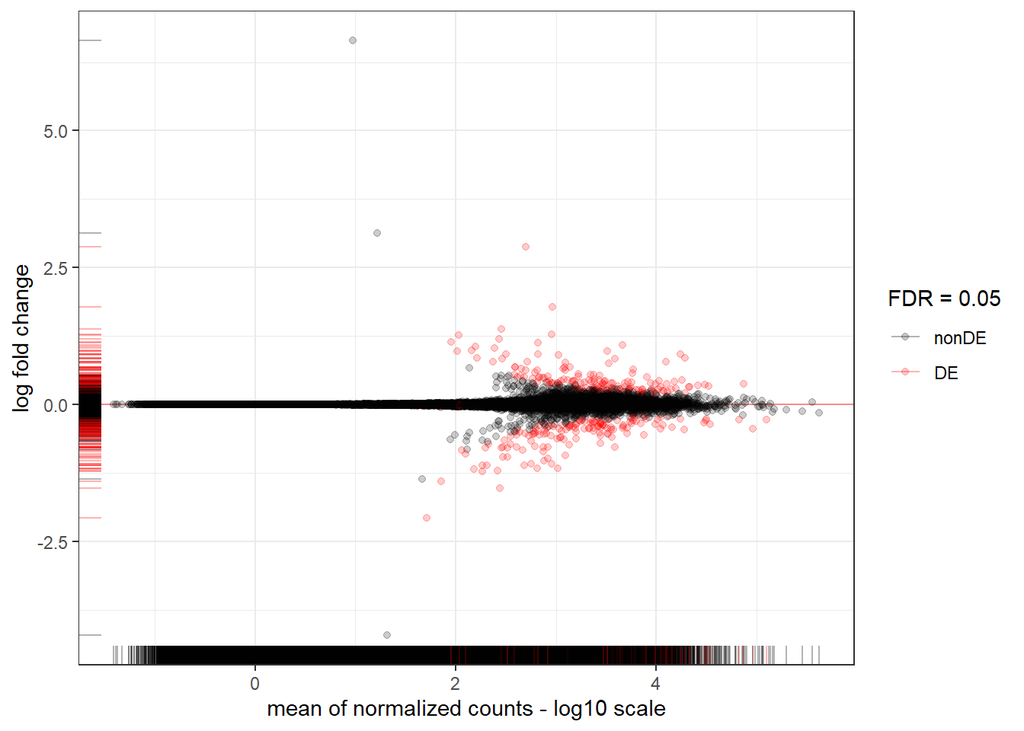

```r
plot_ma(myresuSet_lisamarie[[1]][["res_DESeq"]])
```

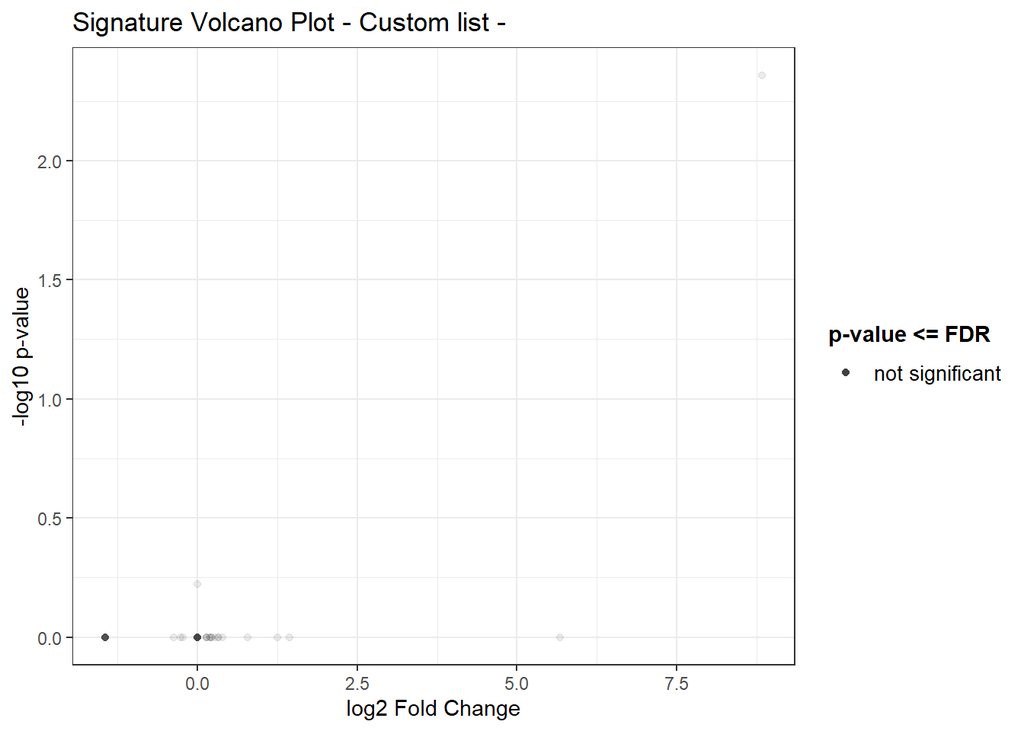

```r
signature_volcano(myresuSet_lisamarie[[2]][["res_DESeq"]], annotation_obj = anno_df)
```

```r
#Volcanoplot doesnt work propperly?
```

# 6 Results functional annotation

We try now to answer the question: “what functions are often associated with the genes that are detected as DE in our experiment”? ## Annotation via topGO

We do this with `topGO`…

```r
expressedInAssay <- (rowSums(assay(dds_lisamarie))>0)
geneUniverseExprENS <- rownames(dds_lisamarie)[expressedInAssay]
geneUniverseExpr <- anno_df$gene_name[match(geneUniverseExprENS, anno_df$gene_id)]
```

We iterate on all contrasts in the `myresuSet` object

```r
#wanted to use res_de and dds here but the list doesn't include the dds does it?
for(i in names(myresuSet_lisamarie)) {
  message(i)
  if(nrow(myresuSet_lisamarie[[i]][["tbl_res_DE"]]) > 0) {
  myresuSet_lisamarie[[i]][["topGO_tbl"]] <-
    topGOtable(de_genes = myresuSet_lisamarie[[i]][["tbl_res_DE"]]$geneSymbol,
               bg_genes  = geneUniverseExpr,
               ontology = "BP",
               geneID = "symbol",
               add_gene_to_terms = TRUE,
               mapping = "org.Hs.eg.db")
  }
}
```

```
## NK_BV6_vs_untrt
```

[output not shown]

[output not shown]

[output not shown]

[output not shown]

[output not shown]

[output not shown]

[output not shown]

[output not shown]

[output not shown]

[output not shown]

[output not shown]

[output not shown]

[output not shown]

[output not shown]

[output not shown]

[output not shown]

[output not shown]

[output not shown]

[output not shown]

[output not shown]

[output not shown]

[output not shown]

[output not shown]

[output not shown]

[output not shown]

[output not shown]

[output not shown]

```
## NKRH30_BV6_vs_untrt
```

[output not shown]

[output not shown]

[output not shown]

[output not shown]

[output not shown]

[output not shown]

[output not shown]

[output not shown]

[output not shown]

```
## RH30_BV6_vs_untrt
```

[output not shown]

[output not shown]

[output not shown]

[output not shown]

[output not shown]

[output not shown]

[output not shown]

[output not shown]

[output not shown]

[output not shown]

[output not shown]

[output not shown]

[output not shown]

[output not shown]

[output not shown]

[output not shown]

[output not shown]

[output not shown]

[output not shown]

[output not shown]

[output not shown]

[output not shown]

[output not shown]

[output not shown]

[output not shown]

[output not shown]

[output not shown]

```r
#for fun look at upreg only


  myresuSet_lisamarie[[1]][["topGO_tbl_upreg"]] <-
    topGOtable(res_de = myresuSet_lisamarie[[1]][["res_DESeq"]],
               dds = dds_NK,
               ontology = "BP",
               geneID = "symbol",
               add_gene_to_terms = TRUE,
               mapping = "org.Hs.eg.db",
               de_type = "up")

  myresuSet_lisamarie[[2]][["topGO_tbl_upreg"]] <-
    topGOtable(res_de = myresuSet_lisamarie[[1]][["res_DESeq"]],
               dds = dds_NKRH30,
               ontology = "BP",
               geneID = "symbol",
               add_gene_to_terms = TRUE,
               mapping = "org.Hs.eg.db",
               de_type = "up")


    myresuSet_lisamarie[[3]][["topGO_tbl_upreg"]] <-
    topGOtable(res_de = myresuSet_lisamarie[[1]][["res_DESeq"]],
               dds = dds_RH30,
               ontology = "BP",
               geneID = "symbol",
               add_gene_to_terms = TRUE,
               mapping = "org.Hs.eg.db",
               de_type = "up")
```

```r
for(i in names(myresuSet_lisamarie)){
    myresuSet_lisamarie[[i]][["topGO_tbl"]] <-
   myresuSet_lisamarie[[i]][["topGO_tbl"]]%>%
     filter(p.value_elim <= 0.05)
    myresuSet_lisamarie[[i]][["topGO_tbl_upreg"]] <-
   myresuSet_lisamarie[[i]][["topGO_tbl_upreg"]]%>%
     filter(p.value_elim <= 0.05)

        myresuSet_lisamarie[[i]][["topGO_tbl"]]$GO_button <- create_link_GO(myresuSet_lisamarie[[i]][["topGO_tbl"]]$GO.ID)
myresuSet_lisamarie[[i]][["topGO_tbl"]] <-
  myresuSet_lisamarie[[i]][["topGO_tbl"]] %>%
  relocate(GO_button, .before = GO.ID)
        myresuSet_lisamarie[[i]][["topGO_tbl_upreg"]]$GO_button <- create_link_GO(myresuSet_lisamarie[[i]][["topGO_tbl_upreg"]]$GO.ID)
myresuSet_lisamarie[[i]][["topGO_tbl_upreg"]] <-
  myresuSet_lisamarie[[i]][["topGO_tbl_upreg"]] %>%
  relocate(GO_button, .before = GO.ID)

}
DT::datatable(myresuSet_lisamarie$NK_BV6_vs_untrt$topGO_tbl,escape=FALSE, rownames=FALSE)
```

| GO_button | GO.ID | Term | Annotated | Significant | Expected | Rank in p.value_classic | p.value_elim | p.value_classic | genes |
| --- | --- | --- | --- | --- | --- | --- | --- | --- | --- |
| GO:0006096@AMIGO | GO:0006096 | glycolytic process | 89 | 14 | 1.33 | 43 | 9.1e-07 | 5.4e-11 | ALDOA,ALDOC,DDIT4,ENO1,GAPDH,GPI,HIF1A,HK2,IFNG,LDHA,PFKP,PGK1,PGM1,TPI1 |
| GO:0071346@AMIGO | GO:0071346 | cellular response to type II interferon | 118 | 11 | 1.76 | 131 | 1.5e-06 | 1.5e-06 | CCL1,CCL3,CCL3L1,CCL4,GAPDH,GBP4,GBP5,GSN,IFNG,IRF1,TNF |
| GO:0071456@AMIGO | GO:0071456 | cellular response to hypoxia | 139 | 13 | 2.07 | 98 | 3.5e-06 | 1.6e-07 | BNIP3,BNIP3L,EGLN1,ENO1,EPAS1,ERO1A,HIF1A,HILPDA,HYOU1,NDRG1,PGK1,PTGIS,VEGFA |
| GO:0061621@AMIGO | GO:0061621 | canonical glycolysis | 18 | 5 | 0.27 | 162 | 5.2e-06 | 5.2e-06 | ENO1,HK2,PFKP,PGK1,TPI1 |
| GO:0051607@AMIGO | GO:0051607 | defense response to virus | 329 | 17 | 4.91 | 188 | 9.6e-06 | 9.6e-06 | APOBEC3G,BNIP3,BNIP3L,DDIT4,GBP5,IFITM1,IFITM2,IFITM3,IFNG,IRF1,ITGAX,LYST,MAP3K14,OAS3,SPON2,TNF,ZC3H12A |
| GO:0042742@AMIGO | GO:0042742 | defense response to bacterium | 307 | 16 | 4.58 | 203 | 1.6e-05 | 1.6e-05 | CD160,FGR,GBP4,GBP5,GNLY,LTA,LYST,NAGK,NOD2,NOTCH2,OAS3,PLAC8,SPON2,SYK,TAB2,TNF |
| GO:0046597@AMIGO | GO:0046597 | negative regulation of viral entry into host cell | 23 | 5 | 0.34 | 209 | 1.9e-05 | 1.9e-05 | CIITA,GSN,IFITM1,IFITM2,IFITM3 |
| GO:0120162@AMIGO | GO:0120162 | positive regulation of cold-induced thermogenesis | 101 | 9 | 1.51 | 212 | 2e-05 | 2e-05 | EPAS1,IGF1R,KDM3A,KDM6B,MFN2,PLAC8,SCD,SYK,VEGFA |
| GO:0071347@AMIGO | GO:0071347 | cellular response to interleukin-1 | 106 | 9 | 1.58 | 220 | 3e-05 | 3e-05 | CCL1,CCL3,CCL3L1,CCL4,HIF1A,NFKBIA,PLCB1,PTGIS,ZC3H12A |
| GO:0050850@AMIGO | GO:0050850 | positive regulation of calcium-mediated signaling | 42 | 6 | 0.63 | 223 | 3.5e-05 | 3.5e-05 | CCL3,CCL4,CD3E,P2RX5,SYK,TNF |

[output cut: 668 more lines]

```r
DT::datatable(myresuSet_lisamarie$RH30_BV6_vs_untrt$topGO_tbl,escape=FALSE, rownames=FALSE)
```

| GO_button | GO.ID | Term | Annotated | Significant | Expected | Rank in p.value_classic | p.value_elim | p.value_classic | genes |
| --- | --- | --- | --- | --- | --- | --- | --- | --- | --- |
| GO:0038061@AMIGO | GO:0038061 | non-canonical NF-kappaB signal transduction | 136 | 15 | 2.49 | 58 | 1.6e-06 | 3e-08 | BIRC2,BIRC3,CARD14,CYLD,GREM1,LAPTM5,MAP3K14,NFKB1,NFKB2,NFKBIA,PRDX1,PTPN22,RELB,RTKN2,TNFRSF10B |
| GO:0019885@AMIGO | GO:0019885 | antigen processing and presentation of endogenous peptide antigen via MHC class I | 22 | 6 | 0.4 | 126 | 2.1e-06 | 2.1e-06 | B2M,ERAP1,HLA-B,HLA-E,TAP1,TAPBP |
| GO:0045071@AMIGO | GO:0045071 | negative regulation of viral genome replication | 55 | 8 | 1.01 | 156 | 6.7e-06 | 6.7e-06 | CCL5,IFIH1,IFIT1,N4BP1,OASL,RSAD2,TNIP1,ZC3HAV1 |
| GO:0006418@AMIGO | GO:0006418 | tRNA aminoacylation for protein translation | 41 | 7 | 0.75 | 158 | 8.6e-06 | 8.6e-06 | AARS1,CARS1,GARS1,MARS1,SARS1,WARS1,YARS1 |
| GO:0050727@AMIGO | GO:0050727 | regulation of inflammatory response | 391 | 21 | 7.17 | 168 | 1.2e-05 | 1.2e-05 | BCR,BIRC2,BIRC3,CCL5,CYLD,DUSP10,ETS1,HLA-E,IL6ST,KLF4,MMP9,NFKB1,NFKBIA,NT5E,PLK2,SEMA7A,SERPINE1,TNC,TNFAIP3,TNIP1,WNT5A |
| GO:0033209@AMIGO | GO:0033209 | tumor necrosis factor-mediated signaling pathway | 109 | 10 | 2 | 199 | 3.2e-05 | 3.2e-05 | BIRC2,BIRC3,CARD14,CYLD,LAPTM5,NFKBIA,TNFAIP3,TNFRSF19,TRAF1,TRAF3 |
| GO:0010628@AMIGO | GO:0010628 | positive regulation of gene expression | 1151 | 48 | 21.1 | 71 | 3.5e-05 | 7.5e-08 | ANXA2,ATF4,ATP13A2,B2M,C1QTNF1,CCL5,CEBPG,CNTN1,CSF1,DDIT3,ERN1,ETS1,GBP5,HLA-E,IFIH1,IL27RA,IL6ST,IL7R,IRF1,ITGAX,KLF4,LAPTM5,LARP6,MEF2C,MUSTN1,MYOCD,NOG,PANX1,PKM,PPP1R15A,PTPN22,RARA,RIGI,ROBO1,RS… |
| GO:0071222@AMIGO | GO:0071222 | cellular response to lipopolysaccharide | 211 | 14 | 3.87 | 203 | 3.7e-05 | 3.7e-05 | BCR,GBP5,HDAC5,MEF2C,MMP9,NFKB1,NFKBIA,PTPN22,RARA,SERPINE1,TNFAIP3,TNIP1,VIM,WNT5A |
| GO:0007411@AMIGO | GO:0007411 | axon guidance | 233 | 14 | 4.27 | 232 | 0.00011 | 0.00011 | CNTN1,EPHA7,ETV1,NCAM1,NGFR,NOG,NOTCH2,ROBO1,ROBO4,SEMA6B,SEMA7A,TRIO,UNC5B,WNT5A |
| GO:0070424@AMIGO | GO:0070424 | regulation of nucleotide-binding oligomerization domain containing signaling pathway | 15 | 4 | 0.27 | 239 | 0.00013 | 0.00013 | BIRC2,BIRC3,PTPN22,TNFAIP3 |

[output cut: 700 more lines]

# 7 DE, plan A2: focus on nk vs nk-rh30

(not executed since its beside the point of testing mosdef)

```r
# dds_plan_a2 <- dds_lisamarie[ , dds_lisamarie$group %in% c("NK_untrt", "NK_RH30_untrt")]
#
# design(dds_plan_a2) <- ~sample_id + group
#
# dds_plan_a2$sample_id <- droplevels(dds_plan_a2$sample_id)
# dds_plan_a2$group <- droplevels(dds_plan_a2$group)
# dds_plan_a2$treatment <- droplevels(dds_plan_a2$treatment)
#
#
# dds_plan_a2 <- estimateSizeFactors(dds_plan_a2)
# dds_plan_a2 <- DESeq(dds_plan_a2)
#
# resultsNames(dds_plan_a2)
#
# summary(results(dds_plan_a2), alpha = FDR)
#
# design(dds_lisamarie)
#
# summary(results(dds_lisamarie, contrast = c("group", "NK_RH30_untrt", "NK_untrt"), alpha = FDR))
#
# myresuSet_lisamarie <- alltheresults(
#   myresuSet_lisamarie, dds_plan_a2,
#   contrast = c("group_NK_untrt_vs_NK_RH30_untrt"), FDR = FDR,
#   anno_df = anno_df, anns = anns_df, species = "Homo_sapiens")
# names(myresuSet_lisamarie)[4] <- "NK_vs_NK_RH30"
#
# myresuSet_lisamarie$NK_vs_NK_RH30$maplot_res
#
# DT::datatable(myresuSet_lisamarie$NK_vs_NK_RH30$etbl_res_DE, escape = FALSE, rownames = FALSE)
#
# i <- "NK_vs_NK_RH30"
# myresuSet_lisamarie[[i]][["topGO_tbl"]] <-
#   topGOtable(de_genes = myresuSet_lisamarie[[i]][["tbl_res_DE"]]$geneSymbol,
#              bg_genes = geneUniverseExpr,
#              ontology = "BP",
#              geneID = "symbol",
#              add_gene_to_terms =TRUE,
#              mapping = "org.Hs.eg.db")
#
# DT::datatable(myresuSet_lisamarie$NK_vs_NK_RH30$topGO_tbl)
#
# message(i)
# myresuSet_lisamarie[[i]][["clupro_tbl"]] <-
#   enrichGO(
#     gene = myresuSet_lisamarie[[i]][["tbl_res_DE"]]$geneSymbol,
#     universe      = geneUniverseExpr,
#     keyType       = "SYMBOL",
#     OrgDb         = org.Hs.eg.db,
#     ont           = "BP",
#     pAdjustMethod = "BH",
#     pvalueCutoff  = 0.01,
#     qvalueCutoff  = 0.05,
#     readable      = FALSE)
#
# DT::datatable(as.data.frame(myresuSet_lisamarie$NK_vs_NK_RH30$clupro_tbl), rownames = FALSE)
#
# emapplot(enrichplot::pairwise_termsim(myresuSet_lisamarie$NK_vs_NK_RH30$clupro_tbl))
#
# de_genes <- myresuSet_lisamarie[[i]][["tbl_res_DE"]]$id
# de_entrez <- clusterProfiler::bitr(de_genes, "ENSEMBL", "ENTREZID", org.Hs.eg.db)$ENTREZID
# universe_entrez <- clusterProfiler::bitr(geneUniverseExprENS, "ENSEMBL", "ENTREZID", org.Hs.eg.db)$ENTREZID
#
# myresuSet_lisamarie[[i]][["reactome_tbl"]] <-
#   enrichPathway(gene = de_entrez,
#                 universe = universe_entrez,
#                 pvalueCutoff = 0.1,
#                 organism = "human",
#                 readable=TRUE)
#
# DT::datatable(as.data.frame(myresuSet_lisamarie$NK_vs_NK_RH30$reactome_tbl), rownames = FALSE)
#
# emapplot(enrichplot::pairwise_termsim(myresuSet_lisamarie$NK_vs_NK_RH30$reactome_tbl))
```